# Models for Supervised Learning

May 30, 2018

## Supervised learning

- `Regression` problem: when response \(Y\) is quantitative
  - linear
  - polynomial
- Decision Tree
- Random Forest
- `Classification` problem: when response \(Y\) is qualitative
  - KNN
  - Trees
  - logistic regression
  - LDA
  - SVM

## Linear Model

- We have input vector \(X^T = \{X_1, X_2,..., X_p\}\) to predict output \(Y\)
  - some of the input variables could be derived from existing variables
  - when some transformation is used, it may create a polynomial regression
- Model: \(f(X)= \beta_0 + \sum X_j\beta_j\)
- Least square solution: \(\hat \beta = (X^TX)^{-1}X^Ty\)
- Predicted value: \(\hat y = X\hat \beta = X(X^TX)^{-1}X^Ty\)
  - Matrix \(H= X(X^TX)^{-1}X^T\) is called the hat matrix or projection matrix
- \(Var(\hat \beta) = (X^TX)^{-1}\hat \sigma^2\)
  - if two covariates \(X_j\) and \(X_k\) are correlated, the variance will blow up

## Variable Selection

- Least square estimates have low bias but large variance
  - Prediction accuracy can sometimes be improved by shrinking or setting some coefficients to zero
  - less covariates is good for interpretability
- Subset Selection
  - allows to explore which subset of the covariates are to use
  - requires all possible subsets to be examined
- Forward and Backward-Stepwise Selection
  - preferred for computational feasibility when \(p\) is large
  - may produce bias
- Forward-Stagewise Regression: first just fit model \(\bar y\). Start with covariate having largest correlation with residuals and proceed.

## Shrinkage Methods

- Ridge Regression: penalize for larger coefficient (\(\beta\))
  - \(\hat \beta =\underset{\beta} argmin \{(y-\beta_0 - \sum X_j \beta_j)^2 + \lambda\sum \beta_j^2\}\)
- The Lasso: It is similar to Ridge but penalty is given by \(\sum |\beta_j| <t\)
  - \(\hat \beta =\underset{\beta} argmin \{(y-\beta_0 - \sum X_j \beta_j)^2 + \lambda\sum |\beta_j|\}\)
  - tuning parameter \(t\) can be obtained by \(k\)-fold cross-validation. if \(t > \sum |\hat \beta_j|\), Lasso will produce Least Square estimates. Shrinkage factor \(s = t/\sum |\hat \beta_j|\)
- Least Angle Regression: forward selection, but add multiple variables in a step
- Methods Using Derived Input Directions
  - Principal Components(PC) Regression: Obtain \(M\) PC and fit regression
  - Partial Least Squares: Similar to PC but uses \(y\) in addition to \(X\)

## Linear models with categorical response

- Linear regression with categorical response (with K categories)
  - create \(k\) indicator variables \(Y = (Y_1, Y_2, ..., Y_k)\)
  - \(\hat Y = X(X^TX)^{-1}X^Ty\)
- Logistic regression: response \(Y\) has \(K\) categories with odds ratio \(OR_k = \frac {Pr(Y=k|X)}{Pr(Y=K|X)}\)
  - fit \(K-1\) models \(log(OR_k) = \beta_{k0} + \beta_k^T X\)
  - \(Pr(Y=k|X) = \frac{e^{\beta_{k0} + \beta_k^T X}}{1+ \sum e^{\beta_{k0} + \beta_k^T X}} , k=1,2,..., K-1\)
- Linear Discriminant Analysis (LDA)
  - assumes multivariate normal with equal covariance matrix for all categories
  - boundaries of different class is linear

## LDA process

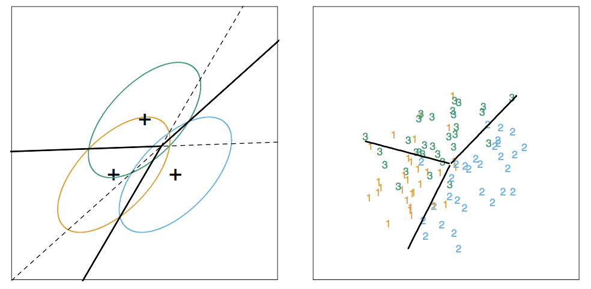

- Linear discriminant function \(\delta_k(x) = x^T\Sigma^{-1}\mu_k - \frac 1 2 \mu_k^T\Sigma^{-1}\mu_k + log (\pi_k)\)
- decision rule: maximize \(\delta_k(x)\) for class k

## non-linear models

- What if function \(f(X)\) is not linear?
  - \(f(X) = \sum \beta_m h_m(X)\)
- \(h_m(X) =X\) gives linear model
- \(h_m(X) =X^p\) gives polynomial
- \(h_m(X) =log(X) or \sqrt X\) and other nonlinear transformation
- \(h_m(X) = I(L_m <X_k<U_m)\) gives piecewise non-overlapping regions
  - piecewise polynomial and spline
  - KNN
- Kernel smoothing methods

## Piecewise Linear

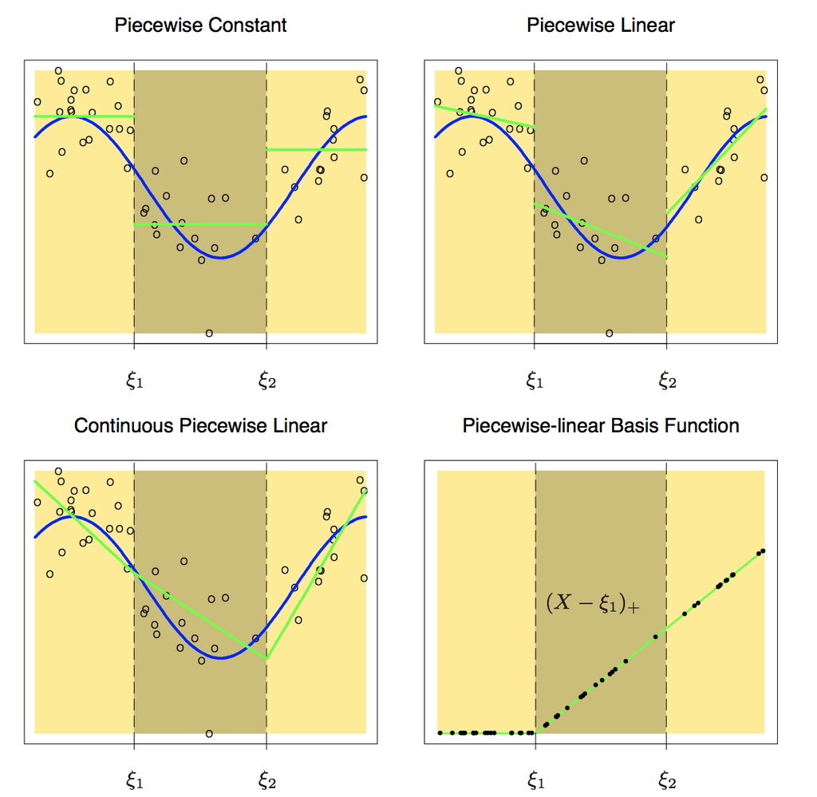

## Piecewise Cubic Polynomial

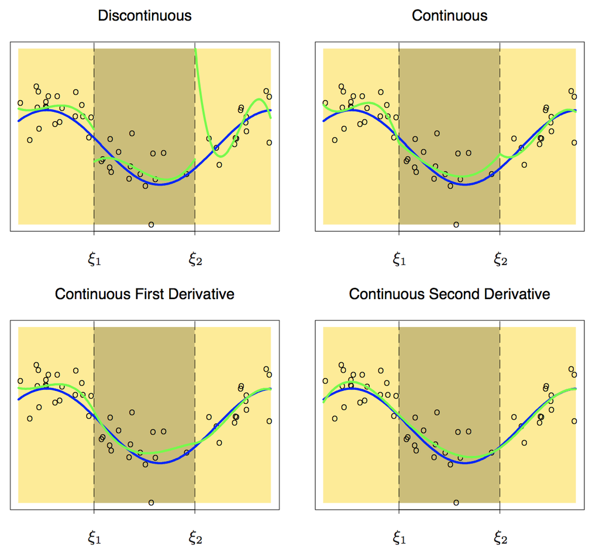

## Generalized Additive Models (GAM)

- \(g[\mu(X)] = \alpha + f_1(X_1) + f_2(X_2) + ... + f_p(X_p)\)
  - \(g[\mu] = \mu\) and \(f_j(X_j)=\beta_jX_j\) gives linear regression
  - \(g[\mu] = logit(\mu)\) and \(f_j(X_j)=\beta_jX_j\) gives logistic regression
- Usually the functions \(f_j()\) are estimated using spline
  - this takes care of non-linearity issues

## Fitting Generalized Additive Models in R

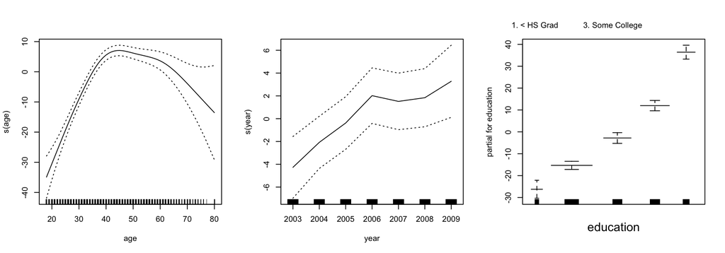

```r
library(gam)
library(ISLR) # to get data for our text book
fit <- gam(wage ~ s(age) + s(year) + education, data = Wage)
# summary(fit)
par(mfrow=c(1,3))
plot(fit, se=TRUE)
```

## Tree based method

- Tree types
  - regression: quantitative \(Y\)
    - \(f(X) = \sum c_m I(x \in R_m)\)
    - \(c_m = avg(y_i|x_i \in R_m)\)
    - classify using split point
  - classification: qualitative \(Y\)
    - \(P_{mk}= \frac 1{N_m}\sum_{x_i \in R_m}I(y_i=k)\)
    - classify observation in node \(m\) to class \(k\) such that \(k(m)=argmax_k P_{mk}\)
- First partition the input space and then fit model such as mean for each partition.

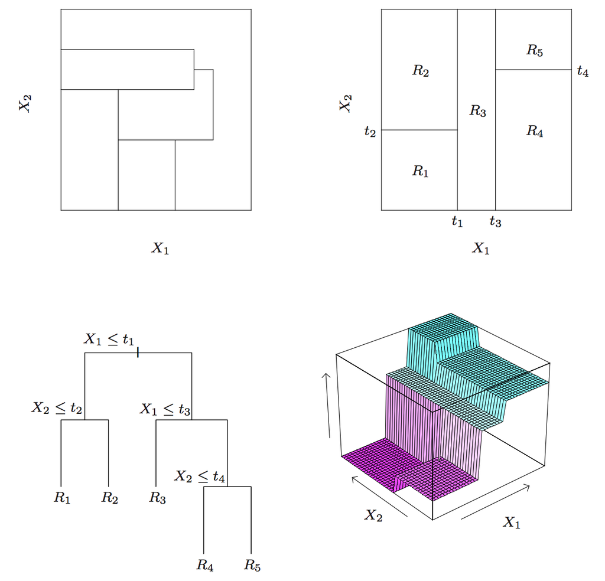

## Improving Prediction

- A week classifier: slightly better than random guessing
  - The predictions from many weak classifiers are combined to produce the final prediction with less variability
- Bagging (bootstrap aggregation)
  - resamples training data and aggregate results
- Random forest
  - Similar to bagging but with a tweak that decorrelates the trees
- Boosting
  - not based on bootstrapping. Each tree is fit to a modified version of previous data set
  - successive trees are obtained based on previous tree

## Neural Network

- Two stage method for
  - regression: quantitative \(Y\)
  - classification: qualitative \(Y\)
- hidden layer
  - \(Z_m = \sigma(\alpha_{0m}+ \alpha_m^TX)\)
  - can be more than one hidden layer
- Activation function
  - \(\sigma(v) = 1/(1+e^{-v})\)
  - called sigmoid function
- \(f_k(X) = g_k(\beta_{0k} + \beta_k^TZ)\)
  - \(g_k(T) = \frac {e^{T_k}}{\sum e^{T_k}}\)

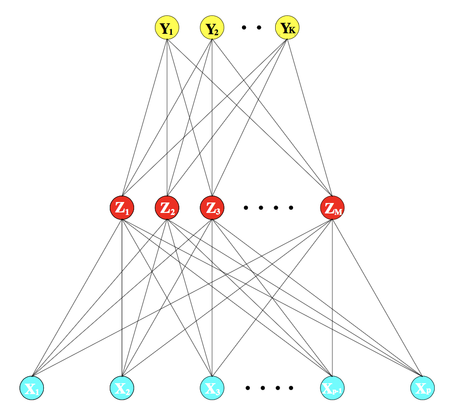

## Support Vector Machine (SVM)

- Supervise learning that can be used for
  - regression
  - classification
- The algorithm finds a hyperplane that best separates the response categories
  - gamma: larger value tries to fit exact kernel (may over fit)
  - cost: penalty for errors. larger value will compromise the smoothness of hyperplane
  - kernel: smoothing method for hyperplane

## Fitting SVM Using R

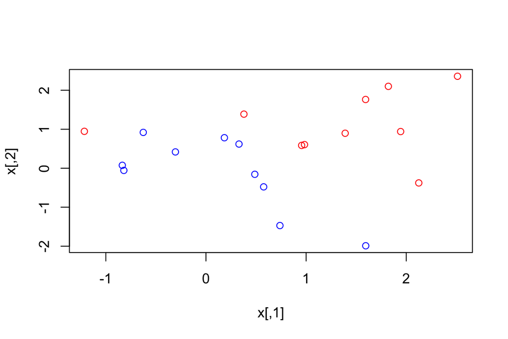

```r
set.seed (1)
x  <- matrix(rnorm(20*2), ncol=2)
y <- c(rep(-1,10), rep(1,10))
x[y==1,] <- x[y==1,] + 1
plot(x, col=(3-y))
```

## Fitting SVM Using R

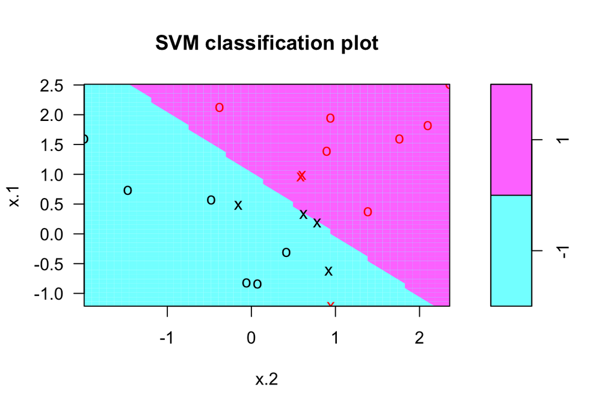

```r
library(e1071)
dat <- data.frame(x=x, y=as.factor(y))
fit <- svm(y~., data=dat, kernel="linear", cost=10, scale=FALSE)
plot(fit,dat)
```

## SVM with non-linear Kernel

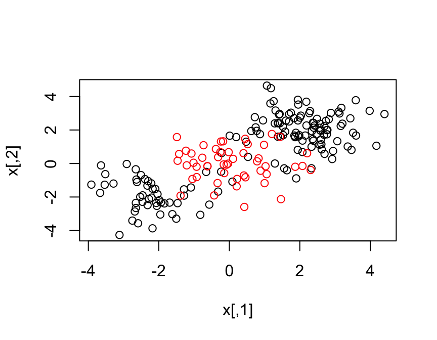

```r
set.seed (1)
x <- matrix(rnorm(200*2), ncol=2)
x[1:100,] <- x[1:100,]+2
x[101:150,] <- x[101:150,]-2
y <- c(rep(1,150),rep(2,50))
dat <- data.frame(x=x,y=as.factor(y))
plot(x, col=y)
```

## SVM with non-linear Kernel

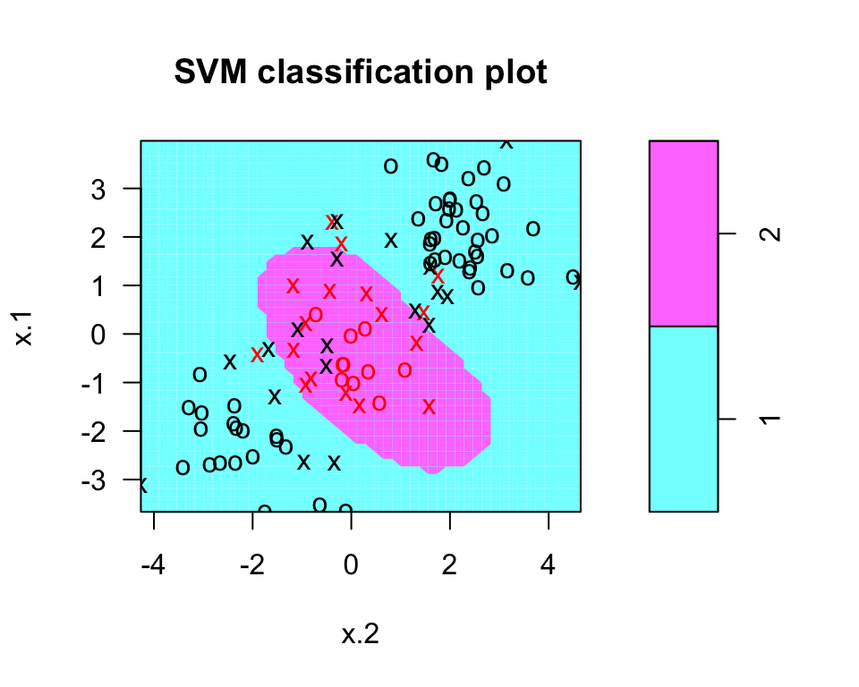

```r
train <- sample(200,100)
fit <- svm(y~., data=dat[train,], kernel="radial", gamma=1, cost =1)
plot(fit , dat[train ,])
```

## ROC curve

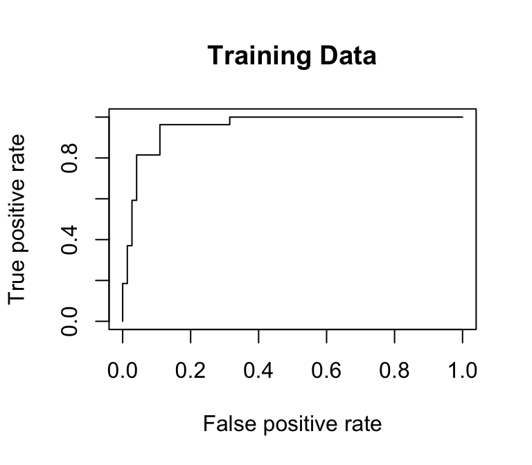

```r
library(ROCR)
rocplot=function(pred, truth, ...){
  predob = prediction (pred, truth)
  perf = performance (predob , "tpr", "fpr")
  plot(perf ,...)}
fitted <- attributes(predict(fit, dat[train,], decision.values=TRUE))$decision.values
rocplot(fitted ,dat[train,"y"],main="Training Data")
```

## Tuning Model Parameters

```r
set.seed (1)
tune.out <- tune(svm, y~., data=dat[train,], kernel="radial",
                 ranges=list(cost=c(0.1,1,10,100,1000),
                             gamma=c(0.5,1,2,3,4)))
summary(tune.out)
```

```
##
## Parameter tuning of 'svm':
##
## - sampling method: 10-fold cross validation
##
## - best parameters:
##  cost gamma
##     1     2
##
## - best performance: 0.12
##
## - Detailed performance results:
##     cost gamma error dispersion
## 1  1e-01   0.5  0.27 0.11595018
## 2  1e+00   0.5  0.13 0.08232726
## 3  1e+01   0.5  0.15 0.07071068
## 4  1e+02   0.5  0.17 0.08232726
## 5  1e+03   0.5  0.21 0.09944289
## 6  1e-01   1.0  0.25 0.13540064
## 7  1e+00   1.0  0.13 0.08232726
## 8  1e+01   1.0  0.16 0.06992059
## 9  1e+02   1.0  0.20 0.09428090
## 10 1e+03   1.0  0.20 0.08164966
## 11 1e-01   2.0  0.25 0.12692955
## 12 1e+00   2.0  0.12 0.09189366
## 13 1e+01   2.0  0.17 0.09486833
## 14 1e+02   2.0  0.19 0.09944289
## 15 1e+03   2.0  0.20 0.09428090
## 16 1e-01   3.0  0.27 0.11595018
## 17 1e+00   3.0  0.13 0.09486833
## 18 1e+01   3.0  0.18 0.10327956
## 19 1e+02   3.0  0.21 0.08755950
## 20 1e+03   3.0  0.22 0.10327956
## 21 1e-01   4.0  0.27 0.11595018
## 22 1e+00   4.0  0.15 0.10801234
## 23 1e+01   4.0  0.18 0.11352924
## 24 1e+02   4.0  0.21 0.08755950
## 25 1e+03   4.0  0.24 0.10749677
```

## Reading and References

- Chapters 3, 4, 5, 6 and 9, The Elements of Statistical Learning by Hastie at el.
- An Introduction to Statistical Learning with Applications in R by Casella at el.